# Risk Factor Analysis

## Outcome Variable

**Outcome Variable:** sstunted

## Predictor Variables

**Intervention Variable:** birthlen

**Adjustment Set:**

- arm
- sex
- W_mage
- meducyrs
- feducyrs
- vagbrth
- single
- brthmon
- W_parity
- impsan
- delta_W_mage
- delta_meducyrs
- delta_feducyrs
- delta_vagbrth
- delta_single
- delta_brthmon
- delta_W_parity
- delta_impsan

## Stratifying Variables

The analysis was stratified on these variable(s):

- agecat
- studyid
- country

## Data Summary

| agecat | studyid | country | birthlen | sstunted | n_cell | n |
| --- | --- | --- | --- | --- | --- | --- |
| Birth | ki0047075b-MAL-ED | BANGLADESH | >=50 cm | 0 | 29 | 257 |
| Birth | ki0047075b-MAL-ED | BANGLADESH | >=50 cm | 1 | 0 | 257 |
| Birth | ki0047075b-MAL-ED | BANGLADESH | <48 cm | 0 | 135 | 257 |
| Birth | ki0047075b-MAL-ED | BANGLADESH | <48 cm | 1 | 9 | 257 |
| Birth | ki0047075b-MAL-ED | BANGLADESH | [48-50) cm | 0 | 84 | 257 |
| Birth | ki0047075b-MAL-ED | BANGLADESH | [48-50) cm | 1 | 0 | 257 |
| Birth | ki0047075b-MAL-ED | BRAZIL | >=50 cm | 0 | 34 | 191 |
| Birth | ki0047075b-MAL-ED | BRAZIL | >=50 cm | 1 | 0 | 191 |
| Birth | ki0047075b-MAL-ED | BRAZIL | <48 cm | 0 | 72 | 191 |
| Birth | ki0047075b-MAL-ED | BRAZIL | <48 cm | 1 | 8 | 191 |
| Birth | ki0047075b-MAL-ED | BRAZIL | [48-50) cm | 0 | 77 | 191 |
| Birth | ki0047075b-MAL-ED | BRAZIL | [48-50) cm | 1 | 0 | 191 |
| Birth | ki0047075b-MAL-ED | INDIA | >=50 cm | 0 | 25 | 206 |
| Birth | ki0047075b-MAL-ED | INDIA | >=50 cm | 1 | 0 | 206 |
| Birth | ki0047075b-MAL-ED | INDIA | <48 cm | 0 | 100 | 206 |
| Birth | ki0047075b-MAL-ED | INDIA | <48 cm | 1 | 7 | 206 |
| Birth | ki0047075b-MAL-ED | INDIA | [48-50) cm | 0 | 74 | 206 |
| Birth | ki0047075b-MAL-ED | INDIA | [48-50) cm | 1 | 0 | 206 |
| Birth | ki0047075b-MAL-ED | NEPAL | >=50 cm | 0 | 38 | 173 |
| Birth | ki0047075b-MAL-ED | NEPAL | >=50 cm | 1 | 0 | 173 |
| Birth | ki0047075b-MAL-ED | NEPAL | <48 cm | 0 | 63 | 173 |
| Birth | ki0047075b-MAL-ED | NEPAL | <48 cm | 1 | 6 | 173 |
| Birth | ki0047075b-MAL-ED | NEPAL | [48-50) cm | 0 | 66 | 173 |
| Birth | ki0047075b-MAL-ED | NEPAL | [48-50) cm | 1 | 0 | 173 |
| Birth | ki0047075b-MAL-ED | PERU | >=50 cm | 0 | 34 | 287 |
| Birth | ki0047075b-MAL-ED | PERU | >=50 cm | 1 | 0 | 287 |
| Birth | ki0047075b-MAL-ED | PERU | <48 cm | 0 | 134 | 287 |
| Birth | ki0047075b-MAL-ED | PERU | <48 cm | 1 | 8 | 287 |
| Birth | ki0047075b-MAL-ED | PERU | [48-50) cm | 0 | 111 | 287 |
| Birth | ki0047075b-MAL-ED | PERU | [48-50) cm | 1 | 0 | 287 |

[output cut: 432 more lines]

The following strata were considered:

- agecat: 24 months, studyid: ki0047075b-MAL-ED, country: BANGLADESH
- agecat: 24 months, studyid: ki0047075b-MAL-ED, country: BRAZIL
- agecat: 24 months, studyid: ki0047075b-MAL-ED, country: INDIA
- agecat: 24 months, studyid: ki0047075b-MAL-ED, country: NEPAL
- agecat: 24 months, studyid: ki0047075b-MAL-ED, country: PERU
- agecat: 24 months, studyid: ki0047075b-MAL-ED, country: SOUTH AFRICA
- agecat: 24 months, studyid: ki0047075b-MAL-ED, country: TANZANIA, UNITED REPUBLIC OF
- agecat: 24 months, studyid: ki1000108-CMC-V-BCS-2002, country: INDIA
- agecat: 24 months, studyid: ki1000108-IRC, country: INDIA
- agecat: 24 months, studyid: ki1017093-NIH-Birth, country: BANGLADESH
- agecat: 24 months, studyid: ki1017093b-PROVIDE, country: BANGLADESH
- agecat: 24 months, studyid: ki1017093c-NIH-Crypto, country: BANGLADESH
- agecat: 24 months, studyid: ki1101329-Keneba, country: GAMBIA
- agecat: 24 months, studyid: ki1114097-CMIN, country: BANGLADESH
- agecat: 24 months, studyid: ki1114097-CMIN, country: PERU
- agecat: 24 months, studyid: ki1114097-CONTENT, country: PERU
- agecat: 24 months, studyid: ki1119695-PROBIT, country: BELARUS
- agecat: 24 months, studyid: ki1126311-ZVITAMBO, country: ZIMBABWE
- agecat: 24 months, studyid: ki1135781-COHORTS, country: GUATEMALA
- agecat: 24 months, studyid: ki1135781-COHORTS, country: INDIA
- agecat: 24 months, studyid: ki1135781-COHORTS, country: PHILIPPINES
- agecat: 24 months, studyid: kiGH5241-JiVitA-3, country: BANGLADESH
- agecat: 24 months, studyid: kiGH5241-JiVitA-4, country: BANGLADESH
- agecat: 6 months, studyid: ki0047075b-MAL-ED, country: BANGLADESH
- agecat: 6 months, studyid: ki0047075b-MAL-ED, country: BRAZIL
- agecat: 6 months, studyid: ki0047075b-MAL-ED, country: INDIA
- agecat: 6 months, studyid: ki0047075b-MAL-ED, country: NEPAL
- agecat: 6 months, studyid: ki0047075b-MAL-ED, country: PERU
- agecat: 6 months, studyid: ki0047075b-MAL-ED, country: SOUTH AFRICA
- agecat: 6 months, studyid: ki0047075b-MAL-ED, country: TANZANIA, UNITED REPUBLIC OF
- agecat: 6 months, studyid: ki1000108-CMC-V-BCS-2002, country: INDIA
- agecat: 6 months, studyid: ki1000108-IRC, country: INDIA
- agecat: 6 months, studyid: ki1000109-EE, country: PAKISTAN
- agecat: 6 months, studyid: ki1000109-ResPak, country: PAKISTAN
- agecat: 6 months, studyid: ki1000304b-SAS-CompFeed, country: INDIA
- agecat: 6 months, studyid: ki1017093-NIH-Birth, country: BANGLADESH
- agecat: 6 months, studyid: ki1017093b-PROVIDE, country: BANGLADESH
- agecat: 6 months, studyid: ki1017093c-NIH-Crypto, country: BANGLADESH
- agecat: 6 months, studyid: ki1101329-Keneba, country: GAMBIA
- agecat: 6 months, studyid: ki1114097-CMIN, country: BANGLADESH
- agecat: 6 months, studyid: ki1114097-CMIN, country: BRAZIL
- agecat: 6 months, studyid: ki1114097-CMIN, country: GUINEA-BISSAU
- agecat: 6 months, studyid: ki1114097-CMIN, country: PERU
- agecat: 6 months, studyid: ki1114097-CONTENT, country: PERU
- agecat: 6 months, studyid: ki1119695-PROBIT, country: BELARUS
- agecat: 6 months, studyid: ki1126311-ZVITAMBO, country: ZIMBABWE
- agecat: 6 months, studyid: ki1135781-COHORTS, country: GUATEMALA
- agecat: 6 months, studyid: ki1135781-COHORTS, country: INDIA
- agecat: 6 months, studyid: ki1135781-COHORTS, country: PHILIPPINES
- agecat: 6 months, studyid: kiGH5241-JiVitA-3, country: BANGLADESH
- agecat: 6 months, studyid: kiGH5241-JiVitA-4, country: BANGLADESH
- agecat: Birth, studyid: ki0047075b-MAL-ED, country: BANGLADESH
- agecat: Birth, studyid: ki0047075b-MAL-ED, country: BRAZIL
- agecat: Birth, studyid: ki0047075b-MAL-ED, country: INDIA
- agecat: Birth, studyid: ki0047075b-MAL-ED, country: NEPAL
- agecat: Birth, studyid: ki0047075b-MAL-ED, country: PERU
- agecat: Birth, studyid: ki0047075b-MAL-ED, country: SOUTH AFRICA
- agecat: Birth, studyid: ki0047075b-MAL-ED, country: TANZANIA, UNITED REPUBLIC OF
- agecat: Birth, studyid: ki1000108-CMC-V-BCS-2002, country: INDIA
- agecat: Birth, studyid: ki1000108-IRC, country: INDIA
- agecat: Birth, studyid: ki1000109-EE, country: PAKISTAN
- agecat: Birth, studyid: ki1000109-ResPak, country: PAKISTAN
- agecat: Birth, studyid: ki1000304b-SAS-CompFeed, country: INDIA
- agecat: Birth, studyid: ki1017093-NIH-Birth, country: BANGLADESH
- agecat: Birth, studyid: ki1017093c-NIH-Crypto, country: BANGLADESH
- agecat: Birth, studyid: ki1101329-Keneba, country: GAMBIA
- agecat: Birth, studyid: ki1114097-CMIN, country: BANGLADESH
- agecat: Birth, studyid: ki1114097-CMIN, country: BRAZIL
- agecat: Birth, studyid: ki1114097-CMIN, country: PERU
- agecat: Birth, studyid: ki1114097-CONTENT, country: PERU
- agecat: Birth, studyid: ki1119695-PROBIT, country: BELARUS
- agecat: Birth, studyid: ki1126311-ZVITAMBO, country: ZIMBABWE
- agecat: Birth, studyid: ki1135781-COHORTS, country: GUATEMALA
- agecat: Birth, studyid: ki1135781-COHORTS, country: INDIA
- agecat: Birth, studyid: ki1135781-COHORTS, country: PHILIPPINES
- agecat: Birth, studyid: kiGH5241-JiVitA-3, country: BANGLADESH
- agecat: Birth, studyid: kiGH5241-JiVitA-4, country: BANGLADESH

### Dropped Strata

Some strata were dropped due to rare outcomes:

- agecat: Birth, studyid: ki0047075b-MAL-ED, country: BANGLADESH
- agecat: Birth, studyid: ki0047075b-MAL-ED, country: BRAZIL
- agecat: Birth, studyid: ki0047075b-MAL-ED, country: INDIA
- agecat: Birth, studyid: ki0047075b-MAL-ED, country: NEPAL
- agecat: Birth, studyid: ki0047075b-MAL-ED, country: PERU
- agecat: Birth, studyid: ki0047075b-MAL-ED, country: SOUTH AFRICA
- agecat: Birth, studyid: ki0047075b-MAL-ED, country: TANZANIA, UNITED REPUBLIC OF
- agecat: Birth, studyid: ki1000108-CMC-V-BCS-2002, country: INDIA
- agecat: Birth, studyid: ki1000108-IRC, country: INDIA
- agecat: Birth, studyid: ki1000109-EE, country: PAKISTAN
- agecat: Birth, studyid: ki1000109-ResPak, country: PAKISTAN
- agecat: Birth, studyid: ki1000304b-SAS-CompFeed, country: INDIA
- agecat: Birth, studyid: ki1017093-NIH-Birth, country: BANGLADESH
- agecat: Birth, studyid: ki1017093c-NIH-Crypto, country: BANGLADESH
- agecat: Birth, studyid: ki1101329-Keneba, country: GAMBIA
- agecat: Birth, studyid: ki1114097-CMIN, country: BANGLADESH
- agecat: Birth, studyid: ki1114097-CMIN, country: BRAZIL
- agecat: Birth, studyid: ki1114097-CMIN, country: PERU
- agecat: Birth, studyid: ki1114097-CONTENT, country: PERU
- agecat: Birth, studyid: ki1119695-PROBIT, country: BELARUS
- agecat: Birth, studyid: ki1126311-ZVITAMBO, country: ZIMBABWE
- agecat: Birth, studyid: ki1135781-COHORTS, country: GUATEMALA
- agecat: Birth, studyid: ki1135781-COHORTS, country: INDIA
- agecat: Birth, studyid: ki1135781-COHORTS, country: PHILIPPINES
- agecat: Birth, studyid: kiGH5241-JiVitA-3, country: BANGLADESH
- agecat: Birth, studyid: kiGH5241-JiVitA-4, country: BANGLADESH
- agecat: 6 months, studyid: ki0047075b-MAL-ED, country: BANGLADESH
- agecat: 6 months, studyid: ki0047075b-MAL-ED, country: BRAZIL
- agecat: 6 months, studyid: ki0047075b-MAL-ED, country: INDIA
- agecat: 6 months, studyid: ki0047075b-MAL-ED, country: NEPAL
- agecat: 6 months, studyid: ki0047075b-MAL-ED, country: PERU
- agecat: 6 months, studyid: ki0047075b-MAL-ED, country: SOUTH AFRICA
- agecat: 6 months, studyid: ki0047075b-MAL-ED, country: TANZANIA, UNITED REPUBLIC OF
- agecat: 6 months, studyid: ki1000108-CMC-V-BCS-2002, country: INDIA
- agecat: 6 months, studyid: ki1000108-IRC, country: INDIA
- agecat: 6 months, studyid: ki1000109-EE, country: PAKISTAN
- agecat: 6 months, studyid: ki1000109-ResPak, country: PAKISTAN
- agecat: 6 months, studyid: ki1017093-NIH-Birth, country: BANGLADESH
- agecat: 6 months, studyid: ki1017093b-PROVIDE, country: BANGLADESH
- agecat: 6 months, studyid: ki1017093c-NIH-Crypto, country: BANGLADESH
- agecat: 6 months, studyid: ki1114097-CMIN, country: BANGLADESH
- agecat: 6 months, studyid: ki1114097-CMIN, country: BRAZIL
- agecat: 6 months, studyid: ki1114097-CMIN, country: GUINEA-BISSAU
- agecat: 6 months, studyid: ki1114097-CMIN, country: PERU
- agecat: 6 months, studyid: ki1114097-CONTENT, country: PERU
- agecat: 24 months, studyid: ki0047075b-MAL-ED, country: BANGLADESH
- agecat: 24 months, studyid: ki0047075b-MAL-ED, country: BRAZIL
- agecat: 24 months, studyid: ki0047075b-MAL-ED, country: INDIA
- agecat: 24 months, studyid: ki0047075b-MAL-ED, country: NEPAL
- agecat: 24 months, studyid: ki0047075b-MAL-ED, country: PERU
- agecat: 24 months, studyid: ki0047075b-MAL-ED, country: SOUTH AFRICA
- agecat: 24 months, studyid: ki0047075b-MAL-ED, country: TANZANIA, UNITED REPUBLIC OF
- agecat: 24 months, studyid: ki1000108-CMC-V-BCS-2002, country: INDIA
- agecat: 24 months, studyid: ki1017093-NIH-Birth, country: BANGLADESH
- agecat: 24 months, studyid: ki1017093b-PROVIDE, country: BANGLADESH
- agecat: 24 months, studyid: ki1017093c-NIH-Crypto, country: BANGLADESH
- agecat: 24 months, studyid: ki1114097-CMIN, country: BANGLADESH
- agecat: 24 months, studyid: ki1114097-CMIN, country: PERU
- agecat: 24 months, studyid: ki1114097-CONTENT, country: PERU
- agecat: 24 months, studyid: ki1119695-PROBIT, country: BELARUS

## Methods Detail

We’re interested in the causal parameters $E[Y_a]$ for all values of $a \in \mathcal{A}$. These parameters represent the mean outcome if, possibly contrary to fact, we intervened to set all units to have $A=a$. Under the randomization and positivity assumptions, these are identified by the statistical parameters $\psi_a=E_W[E_{Y|A,W}(Y|A=a,W)]$. In addition, we’re interested in the mean of $Y$, $E[Y]$ under no intervention (the observed mean). We will estimate these parameters by using SuperLearner to fit the relevant likelihood factors – $E_{Y|A,W}(Y|A=a,W)$ and $p(A=a|W)$, and then updating our likelihood fit using a joint TMLE.

For unadjusted analyses ($W=\{\}$), initial likelihoods were estimated using Lrnr_glm to estimate the simple $E(Y|A)$ and Lrnr_mean to estimate $p(A)$. For adjusted analyses, a small library containing Lrnr_glmnet, Lrnr_xgboost, and Lrnr_mean was used.

Having estimated these parameters, we will then use the delta method to estimate relative risks and attributable risks relative to a prespecified baseline level of $A$.

# Results Detail

## Results Plots

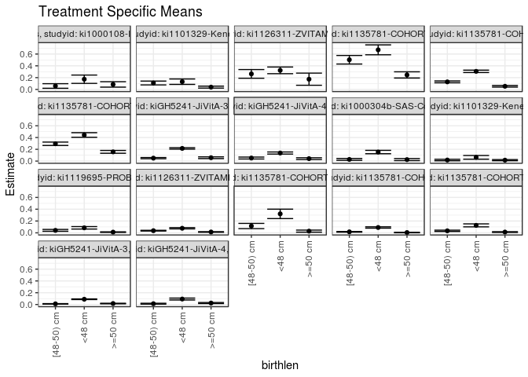

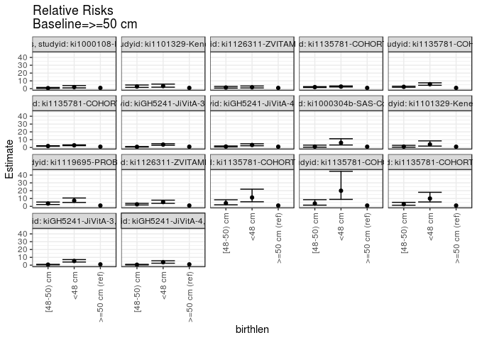

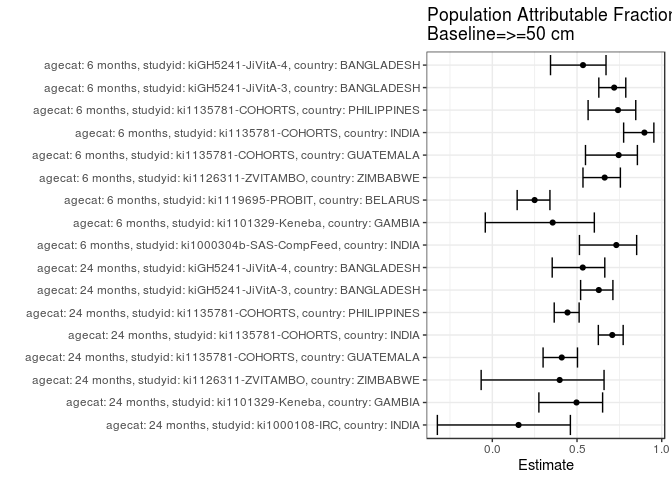

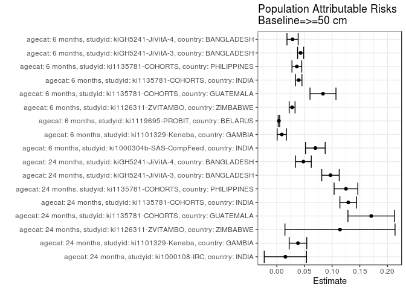

## Results Table

### Parameter: TSM

| agecat | studyid | country | intervention_level | baseline_level | estimate | ci_lower | ci_upper |
| --- | --- | --- | --- | --- | --- | --- | --- |
| 6 months | ki1000304b-SAS-CompFeed | INDIA | >=50 cm | NA | 0.0255102 | 0.0084713 | 0.0425492 |
| 6 months | ki1000304b-SAS-CompFeed | INDIA | <48 cm | NA | 0.1537377 | 0.1251875 | 0.1822879 |
| 6 months | ki1000304b-SAS-CompFeed | INDIA | [48-50) cm | NA | 0.0286396 | 0.0129545 | 0.0443247 |
| 6 months | ki1101329-Keneba | GAMBIA | >=50 cm | NA | 0.0162482 | 0.0067211 | 0.0257752 |
| 6 months | ki1101329-Keneba | GAMBIA | <48 cm | NA | 0.0641026 | 0.0327081 | 0.0954970 |
| 6 months | ki1101329-Keneba | GAMBIA | [48-50) cm | NA | 0.0183486 | 0.0057464 | 0.0309508 |
| 6 months | ki1119695-PROBIT | BELARUS | >=50 cm | NA | 0.0115699 | 0.0065729 | 0.0165668 |
| 6 months | ki1119695-PROBIT | BELARUS | <48 cm | NA | 0.0843865 | 0.0634929 | 0.1052800 |
| 6 months | ki1119695-PROBIT | BELARUS | [48-50) cm | NA | 0.0415575 | 0.0258297 | 0.0572854 |
| 6 months | ki1126311-ZVITAMBO | ZIMBABWE | >=50 cm | NA | 0.0140377 | 0.0092564 | 0.0188190 |
| 6 months | ki1126311-ZVITAMBO | ZIMBABWE | <48 cm | NA | 0.0769828 | 0.0668051 | 0.0871605 |
| 6 months | ki1126311-ZVITAMBO | ZIMBABWE | [48-50) cm | NA | 0.0361580 | 0.0296783 | 0.0426377 |
| 6 months | ki1135781-COHORTS | GUATEMALA | >=50 cm | NA | 0.0284570 | 0.0109211 | 0.0459928 |
| 6 months | ki1135781-COHORTS | GUATEMALA | <48 cm | NA | 0.3214250 | 0.2415098 | 0.4013403 |
| 6 months | ki1135781-COHORTS | GUATEMALA | [48-50) cm | NA | 0.1152139 | 0.0706079 | 0.1598200 |
| 6 months | ki1135781-COHORTS | INDIA | >=50 cm | NA | 0.0045113 | 0.0009094 | 0.0081131 |
| 6 months | ki1135781-COHORTS | INDIA | <48 cm | NA | 0.0901186 | 0.0789596 | 0.1012775 |
| 6 months | ki1135781-COHORTS | INDIA | [48-50) cm | NA | 0.0162637 | 0.0110657 | 0.0214618 |
| 6 months | ki1135781-COHORTS | PHILIPPINES | >=50 cm | NA | 0.0126154 | 0.0056800 | 0.0195509 |
| 6 months | ki1135781-COHORTS | PHILIPPINES | <48 cm | NA | 0.1263093 | 0.1010374 | 0.1515812 |
| 6 months | ki1135781-COHORTS | PHILIPPINES | [48-50) cm | NA | 0.0339556 | 0.0228806 | 0.0450306 |
| 6 months | kiGH5241-JiVitA-3 | BANGLADESH | >=50 cm | NA | 0.0168176 | 0.0119980 | 0.0216371 |
| 6 months | kiGH5241-JiVitA-3 | BANGLADESH | <48 cm | NA | 0.0893984 | 0.0836161 | 0.0951807 |
| 6 months | kiGH5241-JiVitA-3 | BANGLADESH | [48-50) cm | NA | 0.0111553 | 0.0070721 | 0.0152386 |
| 6 months | kiGH5241-JiVitA-4 | BANGLADESH | >=50 cm | NA | 0.0247338 | 0.0157740 | 0.0336935 |
| 6 months | kiGH5241-JiVitA-4 | BANGLADESH | <48 cm | NA | 0.0927683 | 0.0767328 | 0.1088039 |
| 6 months | kiGH5241-JiVitA-4 | BANGLADESH | [48-50) cm | NA | 0.0136543 | 0.0062710 | 0.0210377 |
| 24 months | ki1000108-IRC | INDIA | >=50 cm | NA | 0.0845070 | 0.0386997 | 0.1303144 |
| 24 months | ki1000108-IRC | INDIA | <48 cm | NA | 0.1727273 | 0.1019956 | 0.2434590 |
| 24 months | ki1000108-IRC | INDIA | [48-50) cm | NA | 0.0579710 | 0.0189316 | 0.0970105 |
| 24 months | ki1101329-Keneba | GAMBIA | >=50 cm | NA | 0.0387322 | 0.0221074 | 0.0553569 |
| 24 months | ki1101329-Keneba | GAMBIA | <48 cm | NA | 0.1309566 | 0.0846959 | 0.1772173 |
| 24 months | ki1101329-Keneba | GAMBIA | [48-50) cm | NA | 0.1088303 | 0.0763275 | 0.1413331 |
| 24 months | ki1126311-ZVITAMBO | ZIMBABWE | >=50 cm | NA | 0.1730769 | 0.0701373 | 0.2760166 |
| 24 months | ki1126311-ZVITAMBO | ZIMBABWE | <48 cm | NA | 0.3230769 | 0.2661696 | 0.3799843 |
| 24 months | ki1126311-ZVITAMBO | ZIMBABWE | [48-50) cm | NA | 0.2627737 | 0.1889895 | 0.3365579 |
| 24 months | ki1135781-COHORTS | GUATEMALA | >=50 cm | NA | 0.2457239 | 0.1932480 | 0.2981997 |
| 24 months | ki1135781-COHORTS | GUATEMALA | <48 cm | NA | 0.6711884 | 0.5870202 | 0.7553566 |
| 24 months | ki1135781-COHORTS | GUATEMALA | [48-50) cm | NA | 0.5029592 | 0.4301718 | 0.5757467 |
| 24 months | ki1135781-COHORTS | INDIA | >=50 cm | NA | 0.0532070 | 0.0394643 | 0.0669496 |
| 24 months | ki1135781-COHORTS | INDIA | <48 cm | NA | 0.3060835 | 0.2857972 | 0.3263699 |
| 24 months | ki1135781-COHORTS | INDIA | [48-50) cm | NA | 0.1278350 | 0.1122705 | 0.1433995 |
| 24 months | ki1135781-COHORTS | PHILIPPINES | >=50 cm | NA | 0.1567179 | 0.1329996 | 0.1804363 |
| 24 months | ki1135781-COHORTS | PHILIPPINES | <48 cm | NA | 0.4430476 | 0.4040081 | 0.4820871 |
| 24 months | ki1135781-COHORTS | PHILIPPINES | [48-50) cm | NA | 0.2941379 | 0.2654026 | 0.3228732 |
| 24 months | kiGH5241-JiVitA-3 | BANGLADESH | >=50 cm | NA | 0.0573691 | 0.0425479 | 0.0721903 |
| 24 months | kiGH5241-JiVitA-3 | BANGLADESH | <48 cm | NA | 0.2153993 | 0.2028479 | 0.2279508 |
| 24 months | kiGH5241-JiVitA-3 | BANGLADESH | [48-50) cm | NA | 0.0502204 | 0.0401925 | 0.0602484 |
| 24 months | kiGH5241-JiVitA-4 | BANGLADESH | >=50 cm | NA | 0.0419749 | 0.0269747 | 0.0569750 |
| 24 months | kiGH5241-JiVitA-4 | BANGLADESH | <48 cm | NA | 0.1369888 | 0.1194182 | 0.1545594 |
| 24 months | kiGH5241-JiVitA-4 | BANGLADESH | [48-50) cm | NA | 0.0521445 | 0.0358302 | 0.0684589 |

### Parameter: E(Y)

| agecat | studyid | country | intervention_level | baseline_level | estimate | ci_lower | ci_upper |
| --- | --- | --- | --- | --- | --- | --- | --- |
| 6 months | ki1000304b-SAS-CompFeed | INDIA | NA | NA | 0.0951662 | 0.0766361 | 0.1136962 |
| 6 months | ki1101329-Keneba | GAMBIA | NA | NA | 0.0252413 | 0.0168616 | 0.0336210 |
| 6 months | ki1119695-PROBIT | BELARUS | NA | NA | 0.0154178 | 0.0100323 | 0.0208033 |
| 6 months | ki1126311-ZVITAMBO | ZIMBABWE | NA | NA | 0.0416768 | 0.0373526 | 0.0460011 |
| 6 months | ki1135781-COHORTS | GUATEMALA | NA | NA | 0.1119186 | 0.0883438 | 0.1354934 |
| 6 months | ki1135781-COHORTS | INDIA | NA | NA | 0.0441728 | 0.0390306 | 0.0493149 |
| 6 months | ki1135781-COHORTS | PHILIPPINES | NA | NA | 0.0488708 | 0.0407385 | 0.0570030 |
| 6 months | kiGH5241-JiVitA-3 | BANGLADESH | NA | NA | 0.0599103 | 0.0560579 | 0.0637628 |
| 6 months | kiGH5241-JiVitA-4 | BANGLADESH | NA | NA | 0.0532338 | 0.0448583 | 0.0616093 |
| 24 months | ki1000108-IRC | INDIA | NA | NA | 0.1000000 | 0.0701878 | 0.1298122 |
| 24 months | ki1101329-Keneba | GAMBIA | NA | NA | 0.0769953 | 0.0609772 | 0.0930134 |
| 24 months | ki1126311-ZVITAMBO | ZIMBABWE | NA | NA | 0.2873051 | 0.2454033 | 0.3292069 |
| 24 months | ki1135781-COHORTS | GUATEMALA | NA | NA | 0.4163701 | 0.3755781 | 0.4571621 |
| 24 months | ki1135781-COHORTS | INDIA | NA | NA | 0.1823146 | 0.1713461 | 0.1932832 |
| 24 months | ki1135781-COHORTS | PHILIPPINES | NA | NA | 0.2817363 | 0.2638908 | 0.2995817 |
| 24 months | kiGH5241-JiVitA-3 | BANGLADESH | NA | NA | 0.1544292 | 0.1455642 | 0.1632942 |
| 24 months | kiGH5241-JiVitA-4 | BANGLADESH | NA | NA | 0.0900426 | 0.0798078 | 0.1002775 |

### Parameter: RR

| agecat | studyid | country | intervention_level | baseline_level | estimate | ci_lower | ci_upper |
| --- | --- | --- | --- | --- | --- | --- | --- |
| 6 months | ki1000304b-SAS-CompFeed | INDIA | >=50 cm | >=50 cm | 1.0000000 | 1.0000000 | 1.000000 |
| 6 months | ki1000304b-SAS-CompFeed | INDIA | <48 cm | >=50 cm | 6.0265162 | 3.2342085 | 11.229609 |
| 6 months | ki1000304b-SAS-CompFeed | INDIA | [48-50) cm | >=50 cm | 1.1226730 | 0.4128721 | 3.052748 |
| 6 months | ki1101329-Keneba | GAMBIA | >=50 cm | >=50 cm | 1.0000000 | 1.0000000 | 1.000000 |
| 6 months | ki1101329-Keneba | GAMBIA | <48 cm | >=50 cm | 3.9452214 | 1.8377214 | 8.469604 |
| 6 months | ki1101329-Keneba | GAMBIA | [48-50) cm | >=50 cm | 1.1292744 | 0.4577236 | 2.786093 |
| 6 months | ki1119695-PROBIT | BELARUS | >=50 cm | >=50 cm | 1.0000000 | 1.0000000 | 1.000000 |
| 6 months | ki1119695-PROBIT | BELARUS | <48 cm | >=50 cm | 7.2936369 | 4.9796713 | 10.682862 |
| 6 months | ki1119695-PROBIT | BELARUS | [48-50) cm | >=50 cm | 3.5918733 | 2.3544058 | 5.479749 |
| 6 months | ki1126311-ZVITAMBO | ZIMBABWE | >=50 cm | >=50 cm | 1.0000000 | 1.0000000 | 1.000000 |
| 6 months | ki1126311-ZVITAMBO | ZIMBABWE | <48 cm | >=50 cm | 5.4839990 | 3.8060195 | 7.901758 |
| 6 months | ki1126311-ZVITAMBO | ZIMBABWE | [48-50) cm | >=50 cm | 2.5757783 | 1.7530455 | 3.784633 |
| 6 months | ki1135781-COHORTS | GUATEMALA | >=50 cm | >=50 cm | 1.0000000 | 1.0000000 | 1.000000 |
| 6 months | ki1135781-COHORTS | GUATEMALA | <48 cm | >=50 cm | 11.2951316 | 5.8133722 | 21.945954 |
| 6 months | ki1135781-COHORTS | GUATEMALA | [48-50) cm | >=50 cm | 4.0487096 | 1.9558148 | 8.381187 |
| 6 months | ki1135781-COHORTS | INDIA | >=50 cm | >=50 cm | 1.0000000 | 1.0000000 | 1.000000 |
| 6 months | ki1135781-COHORTS | INDIA | <48 cm | >=50 cm | 19.9762846 | 8.9048026 | 44.813115 |
| 6 months | ki1135781-COHORTS | INDIA | [48-50) cm | >=50 cm | 3.6051282 | 1.5255447 | 8.519547 |
| 6 months | ki1135781-COHORTS | PHILIPPINES | >=50 cm | >=50 cm | 1.0000000 | 1.0000000 | 1.000000 |
| 6 months | ki1135781-COHORTS | PHILIPPINES | <48 cm | >=50 cm | 10.0122737 | 5.5814704 | 17.960433 |
| 6 months | ki1135781-COHORTS | PHILIPPINES | [48-50) cm | >=50 cm | 2.6915889 | 1.4208051 | 5.098976 |
| 6 months | kiGH5241-JiVitA-3 | BANGLADESH | >=50 cm | >=50 cm | 1.0000000 | 1.0000000 | 1.000000 |
| 6 months | kiGH5241-JiVitA-3 | BANGLADESH | <48 cm | >=50 cm | 5.3157769 | 3.9658807 | 7.125147 |
| 6 months | kiGH5241-JiVitA-3 | BANGLADESH | [48-50) cm | >=50 cm | 0.6633145 | 0.4200838 | 1.047377 |
| 6 months | kiGH5241-JiVitA-4 | BANGLADESH | >=50 cm | >=50 cm | 1.0000000 | 1.0000000 | 1.000000 |
| 6 months | kiGH5241-JiVitA-4 | BANGLADESH | <48 cm | >=50 cm | 3.7506772 | 2.5171003 | 5.588804 |
| 6 months | kiGH5241-JiVitA-4 | BANGLADESH | [48-50) cm | >=50 cm | 0.5520530 | 0.2861895 | 1.064898 |
| 24 months | ki1000108-IRC | INDIA | >=50 cm | >=50 cm | 1.0000000 | 1.0000000 | 1.000000 |
| 24 months | ki1000108-IRC | INDIA | <48 cm | >=50 cm | 2.0439394 | 1.0361710 | 4.031852 |
| 24 months | ki1000108-IRC | INDIA | [48-50) cm | >=50 cm | 0.6859903 | 0.2889866 | 1.628389 |
| 24 months | ki1101329-Keneba | GAMBIA | >=50 cm | >=50 cm | 1.0000000 | 1.0000000 | 1.000000 |
| 24 months | ki1101329-Keneba | GAMBIA | <48 cm | >=50 cm | 3.3810797 | 1.9387710 | 5.896364 |
| 24 months | ki1101329-Keneba | GAMBIA | [48-50) cm | >=50 cm | 2.8098156 | 1.6673726 | 4.735033 |
| 24 months | ki1126311-ZVITAMBO | ZIMBABWE | >=50 cm | >=50 cm | 1.0000000 | 1.0000000 | 1.000000 |
| 24 months | ki1126311-ZVITAMBO | ZIMBABWE | <48 cm | >=50 cm | 1.8666667 | 1.0038648 | 3.471030 |
| 24 months | ki1126311-ZVITAMBO | ZIMBABWE | [48-50) cm | >=50 cm | 1.5182482 | 0.7865059 | 2.930782 |
| 24 months | ki1135781-COHORTS | GUATEMALA | >=50 cm | >=50 cm | 1.0000000 | 1.0000000 | 1.000000 |
| 24 months | ki1135781-COHORTS | GUATEMALA | <48 cm | >=50 cm | 2.7314745 | 2.1369280 | 3.491439 |
| 24 months | ki1135781-COHORTS | GUATEMALA | [48-50) cm | >=50 cm | 2.0468474 | 1.5862205 | 2.641237 |
| 24 months | ki1135781-COHORTS | INDIA | >=50 cm | >=50 cm | 1.0000000 | 1.0000000 | 1.000000 |
| 24 months | ki1135781-COHORTS | INDIA | <48 cm | >=50 cm | 5.7526979 | 4.4075147 | 7.508434 |
| 24 months | ki1135781-COHORTS | INDIA | [48-50) cm | >=50 cm | 2.4026003 | 1.8067709 | 3.194920 |
| 24 months | ki1135781-COHORTS | PHILIPPINES | >=50 cm | >=50 cm | 1.0000000 | 1.0000000 | 1.000000 |
| 24 months | ki1135781-COHORTS | PHILIPPINES | <48 cm | >=50 cm | 2.8270380 | 2.3746959 | 3.365544 |
| 24 months | ki1135781-COHORTS | PHILIPPINES | [48-50) cm | >=50 cm | 1.8768617 | 1.5692490 | 2.244774 |
| 24 months | kiGH5241-JiVitA-3 | BANGLADESH | >=50 cm | >=50 cm | 1.0000000 | 1.0000000 | 1.000000 |
| 24 months | kiGH5241-JiVitA-3 | BANGLADESH | <48 cm | >=50 cm | 3.7546237 | 2.8777866 | 4.898626 |
| 24 months | kiGH5241-JiVitA-3 | BANGLADESH | [48-50) cm | >=50 cm | 0.8753917 | 0.6314899 | 1.213496 |
| 24 months | kiGH5241-JiVitA-4 | BANGLADESH | >=50 cm | >=50 cm | 1.0000000 | 1.0000000 | 1.000000 |
| 24 months | kiGH5241-JiVitA-4 | BANGLADESH | <48 cm | >=50 cm | 3.2635901 | 2.2370456 | 4.761200 |
| 24 months | kiGH5241-JiVitA-4 | BANGLADESH | [48-50) cm | >=50 cm | 1.2422799 | 0.7698431 | 2.004641 |

### Parameter: PAR

| agecat | studyid | country | intervention_level | baseline_level | estimate | ci_lower | ci_upper |
| --- | --- | --- | --- | --- | --- | --- | --- |
| 6 months | ki1000304b-SAS-CompFeed | INDIA | >=50 cm | NA | 0.0696560 | 0.0518817 | 0.0874302 |
| 6 months | ki1101329-Keneba | GAMBIA | >=50 cm | NA | 0.0089931 | 0.0006416 | 0.0173447 |
| 6 months | ki1119695-PROBIT | BELARUS | >=50 cm | NA | 0.0038479 | 0.0024763 | 0.0052196 |
| 6 months | ki1126311-ZVITAMBO | ZIMBABWE | >=50 cm | NA | 0.0276391 | 0.0223365 | 0.0329417 |
| 6 months | ki1135781-COHORTS | GUATEMALA | >=50 cm | NA | 0.0834617 | 0.0599923 | 0.1069310 |
| 6 months | ki1135781-COHORTS | INDIA | >=50 cm | NA | 0.0396615 | 0.0338486 | 0.0454744 |
| 6 months | ki1135781-COHORTS | PHILIPPINES | >=50 cm | NA | 0.0362553 | 0.0274162 | 0.0450944 |
| 6 months | kiGH5241-JiVitA-3 | BANGLADESH | >=50 cm | NA | 0.0430928 | 0.0376101 | 0.0485755 |
| 6 months | kiGH5241-JiVitA-4 | BANGLADESH | >=50 cm | NA | 0.0285001 | 0.0183828 | 0.0386173 |
| 24 months | ki1000108-IRC | INDIA | >=50 cm | NA | 0.0154930 | -0.0227050 | 0.0536909 |
| 24 months | ki1101329-Keneba | GAMBIA | >=50 cm | NA | 0.0382631 | 0.0223452 | 0.0541810 |
| 24 months | ki1126311-ZVITAMBO | ZIMBABWE | >=50 cm | NA | 0.1142282 | 0.0147400 | 0.2137164 |
| 24 months | ki1135781-COHORTS | GUATEMALA | >=50 cm | NA | 0.1706463 | 0.1285925 | 0.2127000 |
| 24 months | ki1135781-COHORTS | INDIA | >=50 cm | NA | 0.1291077 | 0.1140610 | 0.1441544 |
| 24 months | ki1135781-COHORTS | PHILIPPINES | >=50 cm | NA | 0.1250183 | 0.1035965 | 0.1464402 |
| 24 months | kiGH5241-JiVitA-3 | BANGLADESH | >=50 cm | NA | 0.0970601 | 0.0812935 | 0.1128266 |
| 24 months | kiGH5241-JiVitA-4 | BANGLADESH | >=50 cm | NA | 0.0480678 | 0.0338326 | 0.0623029 |

### Parameter: PAF

| agecat | studyid | country | intervention_level | baseline_level | estimate | ci_lower | ci_upper |
| --- | --- | --- | --- | --- | --- | --- | --- |
| 6 months | ki1000304b-SAS-CompFeed | INDIA | >=50 cm | NA | 0.7319404 | 0.5143576 | 0.8520394 |
| 6 months | ki1101329-Keneba | GAMBIA | >=50 cm | NA | 0.3562864 | -0.0415418 | 0.6021598 |
| 6 months | ki1119695-PROBIT | BELARUS | >=50 cm | NA | 0.2495770 | 0.1466480 | 0.3400910 |
| 6 months | ki1126311-ZVITAMBO | ZIMBABWE | >=50 cm | NA | 0.6631770 | 0.5351391 | 0.7559490 |
| 6 months | ki1135781-COHORTS | GUATEMALA | >=50 cm | NA | 0.7457353 | 0.5499618 | 0.8563443 |
| 6 months | ki1135781-COHORTS | INDIA | >=50 cm | NA | 0.8978720 | 0.7751591 | 0.9536111 |
| 6 months | ki1135781-COHORTS | PHILIPPINES | >=50 cm | NA | 0.7418613 | 0.5654007 | 0.8466735 |
| 6 months | kiGH5241-JiVitA-3 | BANGLADESH | >=50 cm | NA | 0.7192879 | 0.6286395 | 0.7878093 |
| 6 months | kiGH5241-JiVitA-4 | BANGLADESH | >=50 cm | NA | 0.5353753 | 0.3435303 | 0.6711560 |
| 24 months | ki1000108-IRC | INDIA | >=50 cm | NA | 0.1549296 | -0.3244291 | 0.4607910 |
| 24 months | ki1101329-Keneba | GAMBIA | >=50 cm | NA | 0.4969539 | 0.2748218 | 0.6510439 |
| 24 months | ki1126311-ZVITAMBO | ZIMBABWE | >=50 cm | NA | 0.3975850 | -0.0659346 | 0.6595440 |
| 24 months | ki1135781-COHORTS | GUATEMALA | >=50 cm | NA | 0.4098427 | 0.2996400 | 0.5027049 |
| 24 months | ki1135781-COHORTS | INDIA | >=50 cm | NA | 0.7081586 | 0.6257944 | 0.7723941 |
| 24 months | ki1135781-COHORTS | PHILIPPINES | >=50 cm | NA | 0.4437424 | 0.3654120 | 0.5124041 |
| 24 months | kiGH5241-JiVitA-3 | BANGLADESH | >=50 cm | NA | 0.6285088 | 0.5211629 | 0.7117898 |
| 24 months | kiGH5241-JiVitA-4 | BANGLADESH | >=50 cm | NA | 0.5338334 | 0.3534558 | 0.6638880 |